# Linear Regression

## With Scikit-Learn

Linear regression is used to model the relationship between a numeric outcome variable and one or more features by fitting a linear equation to the data. The model estimates coefficients that minimize the sum of squared residuals. Linear Regression is one of the oldest predictive modeling techniques.

### Use Cases

- Predicting housing prices from square footage and location
- Estimating insurance premiums from age and health indicators
- Forecasting company revenue based on marketing spend
- Estimating blood pressure based on age and BMI
- Forecasting electricity demand from temperature and time of day

### Strengths

- Well-understood and extensively used
- Fast and computationally efficient
- Easy to interpret and communicate

### Weaknesses

- Assumes a linear relationship between features and outcome
- Sensitive to multicollinearity, outliers, and missing data
- Cannot capture complex non-linear interactions unless transformed
- Makes a number of assumptions such as constant variance and normally distributed errors

## Overview

This note will begin by introducing the structure and syntax of the Scikit-Learn Library. Next, it will demonstrate the use of Linear Regression with Scikit-Learn illustrating similar models and using the same data as the other note on Linear Regression. Since the data used here is identical to the one used in the other Linear Regression note, sections such as data exploration that would be repetitive are not included in this note. Please review the Linear Regression note with StatsModels before reviewing this note.

## Scikit-Learn

Several Python libraries provide solid implementations of a range of machine learning algorithms. One of the best known is Scikit-Learn, a package that provides efficient versions of a large number of common algorithms. Scikit-Learn is characterized by a clean, uniform, and streamlined API, as well as by very useful and complete documentation. A benefit of this uniformity is that once you understand the basic use and syntax of Scikit-Learn for one type of model, switching to a new model or algorithm is straightforward. In this note, we will provide an overview of Scikit-Learn API.

## Data Representation

- A table is a basic representation of data where rows represent observations and columns represent variables. Rows are referred to as samples and columns features. n_samples is the number of rows and n_features, the number of features.
- The features matrix includes all the features except the outcome or target variable. This is typically a NumPy array or a Pandas DataFrame. It is represented as X.
- The target array includes the outcome or target variable. This is typically 1-d with a length n_samples and represented as a NumPy array or Pandas Series.

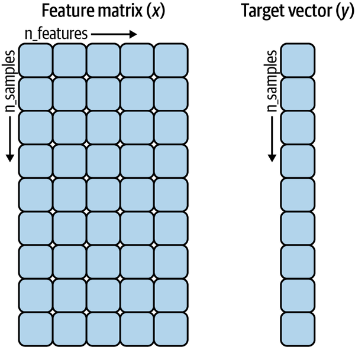

### Guiding Principles

Scikit-Learn is designed with the following principles in mind which are detailed in this [Scikit-Learn API paper](https://arxiv.org/abs/1309.0238).

- Consistency: All objects share a common interface drawn from a limited set of methods, with consistent documentation.
- Inspection: All specified parameter values are exposed as public attributes.
- Limited object hierarchy: Only algorithms are represented by Python classes; datasets are represented in standard formats (NumPy arrays, Pandas DataFrame objects, SciPy sparse matrices) and parameter names use standard Python strings.
- Composition: Many machine learning tasks can be expressed as sequences of more fundamental algorithms, and Scikit-Learn makes use of this wherever possible.
- Sensible defaults: When models require user-specified parameters, the library defines an appropriate default value.

### Basics of the API

- Choose a class of model by importing the appropriate estimator class from Scikit-Learn.
- Choose model hyperparameters by instantiating this class with desired values.
- Arrange data into a features matrix and target vector, as outlined earlier in this chapter.
- Fit the model to your data by calling the fit method of the model instance.
- Apply the model to new data:
  - For supervised learning, often we predict labels for unknown data using the predict method.
  - For unsupervised learning, we often transform or infer properties of the data using the transform or predict method.

## Data Description

Earning data is derived from a survey of individuals on a multitude of characteristics including demographics, physical characteristics, health, well-being and earning. (Original Data Source: Regression and Other stories, by Andrew Gelman, Jennifer Hill, and Avi Vekhtari). We are interested in examining the factors that influence annual earning (`earn`) and predicting an individuals annual earning.

Data consists of characteristics of a set of employees and their annual earning. Variables included are:

- earn: Annual earning in dollars
- age: Age in years
- gender: male, female
- height: Height in inches
- weight: Weight in pounds
- ethnicity: White, African American, Hispanic, Asian
- education: Years of education
- walk: Frequency of taking a walk (in a week)
- exercise: Frequency of strenuous exercise (in a week)
- smokenow: Smoke seven or more cigarettes a week (1 = Yes, 2 = No)
- tense: Days felt tense or anxious

## Read Data

Modeling functions for supervised learning in Scikit-Learn require the outcome variable to separated from the features. So, after reading the data in, features are assigned to X and the outcome to y.

```python
import pandas as pd
data = pd.read_csv('earning.csv')
y = data.earn
X = data.drop('earn', axis=1)
```

```python
y
```

```
0       116500
1       139800
2        69900
3        58250
4       116500
         ...
1780     34950
1781     18640
1782    139800
1783     34950
1784     13980
Name: earn, Length: 1785, dtype: int64
```

## Split Data

Let us start by splitting the data into a train and test sample such that 70% of the data is in the train sample. To ensure the same distribution of the outcome variable across train and test samples, we will sample from a binned outcome variable.

```python
import numpy as np
```

```python
y_binned = pd.cut(x = y, bins = [-1,20000,40000,60000,80000, 100000, 200000,1000000])  # specifying bins because the earn is skewed
from sklearn.model_selection import train_test_split
X_train_raw, X_test_raw, y_train, y_test = train_test_split(X, y,
                                                    train_size=0.7,
                                                    random_state=617, stratify = y_binned)
```

## Transform Data

- Nominal categorical features need to transformed before use in a predictive model.
- Each categorical feature with k levels is represented by k-1 dummy variables.

```python
categorical_features = ['gender','ethnicity','smokenow']

X_train = pd.get_dummies(X_train_raw,
                         prefix_sep = '_',
                         columns = categorical_features,
                         drop_first = True)

X_test = pd.get_dummies(X_test_raw,
                         prefix_sep = '_',
                         columns = categorical_features,
                         drop_first = True)

X_test.reindex(columns=X_train.columns, fill_value=0)
X_train.head()
```

|  | age | height | weight | education | walk | exercise | tense | gender_male | ethnicity_Asian | ethnicity_Hispanic | ethnicity_White | smokenow_2 |
| --- | --- | --- | --- | --- | --- | --- | --- | --- | --- | --- | --- | --- |
| 920 | 74 | 64 | 180 | 12 | 8 | 1 | 0 | False | False | False | True | True |
| 334 | 32 | 65 | 112 | 12 | 6 | 1 | 7 | False | False | False | True | False |
| 91 | 73 | 68 | 170 | 12 | 3 | 7 | 0 | True | False | False | True | False |
| 164 | 43 | 61 | 116 | 18 | 4 | 7 | 2 | False | False | False | True | True |
| 600 | 54 | 70 | 160 | 18 | 1 | 6 | 0 | True | False | False | True | True |

## Explore Data

Exploration has been discussed in the note on linear regression that used statsmodels, therefore it will not be discussed here.

## Fit Model: age

```python
from sklearn.linear_model import LinearRegression
reg = LinearRegression()
reg.fit(X_train.loc[:,['age']], y_train)
```

```
LinearRegression()
```

## Predict

```python
y_pred = reg.predict(X_train.loc[:,['age']])
from sklearn.metrics import root_mean_squared_error
rmse1 = root_mean_squared_error(y_train,y_pred)
y_pred_test = reg.predict(X_test.loc[:,['age']])
rmse1_test = root_mean_squared_error(y_test,y_pred_test)
rmse1
```

```
53252.08079412854
```

## Fit Model: Weight

```python
from sklearn.linear_model import LinearRegression
reg = LinearRegression()
reg.fit(X_train.loc[:,['weight']], y_train)
```

```
LinearRegression()
```

```python
y_pred = reg.predict(X_train.loc[:,['weight']])
rmse2 = root_mean_squared_error(y_train, y_pred)
y_pred_test = reg.predict(X_test.loc[:,['weight']])
rmse2_test = root_mean_squared_error(y_test, y_pred_test)
rmse2
```

```
52539.0232693445
```

## Fit Model: gender

```python
from sklearn.linear_model import LinearRegression
reg = LinearRegression()
reg.fit(X_train.loc[:,['gender_male']], y_train)
y_pred = reg.predict(X_train.loc[:,['gender_male']])
rmse3 = root_mean_squared_error(y_train, y_pred)
y_pred_test = reg.predict(X_test.loc[:,['gender_male']])
rmse3_test = root_mean_squared_error(y_test, y_pred_test)
rmse3
```

```
50479.62615171911
```

## Fit Model: ethnicity

```python
from sklearn.linear_model import LinearRegression
reg = LinearRegression()
reg.fit(X_train.loc[:,['ethnicity_Asian','ethnicity_Hispanic','ethnicity_White']], y_train)
y_pred = reg.predict(X_train.loc[:,['ethnicity_Asian','ethnicity_Hispanic','ethnicity_White']])
rmse4 = root_mean_squared_error(y_train, y_pred)
y_pred_test = reg.predict(X_test.loc[:,['ethnicity_Asian','ethnicity_Hispanic','ethnicity_White']])
rmse4_test = root_mean_squared_error(y_test, y_pred_test)
rmse4
```

```
53145.04489030082
```

## Fit Model: All Predictors

```python
from sklearn.linear_model import LinearRegression
reg = LinearRegression()
reg.fit(X_train, y_train)
y_pred = reg.predict(X_train)
rmse5 = root_mean_squared_error(y_train, y_pred)
y_pred_test = reg.predict(X_test)
rmse5_test = root_mean_squared_error(y_test, y_pred_test)
rmse5
```

```
47516.834777750606
```

## Predict Out of Sample

```python
pd.DataFrame({'model':['age','weight','gender','ethnicity','all'],
              'train_rmse': [rmse1, rmse2,rmse3,rmse4,rmse5],
              'test_rmse': [rmse1_test, rmse2_test, rmse3_test, rmse4_test, rmse5_test]}).set_index('model')
```

| model | train_rmse | test_rmse |
| --- | --- | --- |
| age | 53252.080794 | 51117.057737 |
| weight | 52539.023269 | 50907.445872 |
| gender | 50479.626152 | 49841.934181 |
| ethnicity | 53145.044890 | 51241.972819 |
| all | 47516.834778 | 46030.382854 |

## Summary

In this note, we examined implementation of Linear Regression using Scikit-Learn. The focus of this note was Prediction. We examined linear regression models with

- one numeric feature
- one categorical feature
- multiple features

This file was generated using Python 3.13.5 on Windows 10 with the following libraries: numpy 2.3.1, pandas 2.3.0, scikit-learn 1.7.1